# Analiza danych Spotify

Viktoria Toman

2026-01-13

Celem tego projektu jest przeanalizowanie zestawu najpopularniej słuchanych utworów na platformie Spotify w roku 2025.

Dane pochodzą z https://www.kaggle.com

## Wytłumaczenie poszczególnych nazw kategorii w bazie danych:

Energy A measure of intensity and activity. Typically, energetic tracks feel fast, loud, and noisy.

Tempo The speed of a track, measured in beats per minute (BPM).

Danceability A score describing how suitable a track is for dancing based on tempo, rhythm stability, beat strength and overall regularity.

Loudness The overall loudness of a track in decibels (dB). Higher values indicate louder tracks overall . Liveness The likelihood of a track being performed live. Higher values suggest more audience presence.

Valence The overall musical positiveness(emotion) of a track. High valence sounds happy; low valence sounds sad or angry.

Speechiness Measures the presence of spoken words.

Instrumentalness The likelihood a track contains no vocals. Values closer to 1.0 suggest solely instrumental tracks.

Mode Indicates the modality of the track.

Key The musical key, represented as an integer from 0 to 11, mapping to standard Pitch class notation.

Duration_ms The length of the track in milliseconds.

Acousticness A confidence measure of whether a track is acoustic(1) or not(0).

Track Popularity A score (0–100) which is calculated based on total number of streams in relation to other songs.

## Instalowanie pakietów oraz przygotowanie zestawu danych

```r
knitr::opts_chunk$set(echo = TRUE)
library(dplyr)
```

```
##  /\     /\
## {  `---'  }
## {  O   O  }
## ==>  V <==  No need for mice. This data set is completely observed.
##  \  \|/  /
##   `-----'
```

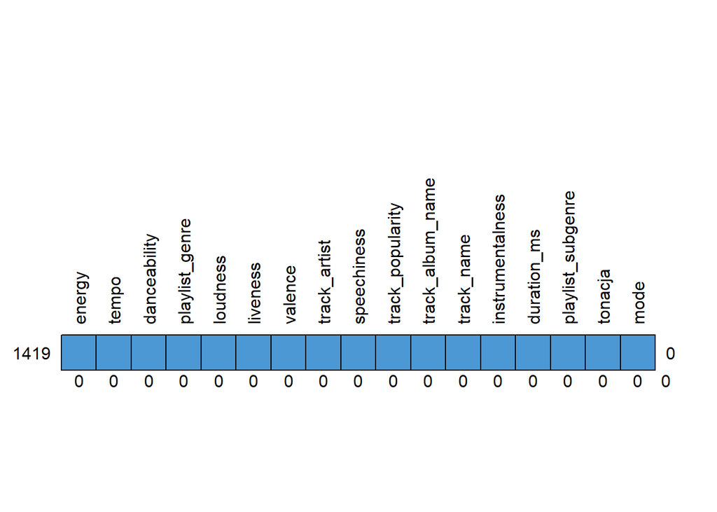

```
##      energy tempo danceability playlist_genre loudness liveness valence
## 1419      1     1            1              1        1        1       1
##           0     0            0              0        0        0       0
##      track_artist speechiness track_popularity track_album_name track_name
## 1419            1           1                1                1          1
##                 0           0                0                0          0
##      instrumentalness duration_ms playlist_subgenre tonacja mode
## 1419                1           1                 1       1    1 0
##                     0           0                 0       0    0 0
```

```r
library(ggplot2)
library(readr)
library(tidyr)
library(mice)
library(corrplot)
high_popularity_spotify_data <- read_csv("high_popularity_spotify_data.csv")
dane <- high_popularity_spotify_data
dane <- na.omit(dane)
dane<- unique(dane)
dane <- distinct(dane, track_name, track_artist, .keep_all = TRUE)

dane$key <- factor(
  dane$key,
  levels = 0:11,
  labels = c(
    "C", "C♯/D♭", "D", "D♯/E♭", "E", "F",
    "F♯/G♭", "G", "G♯/A♭", "A", "A♯/B♭", "B"
  )
)

dane$mode <- factor(dane$mode, levels = 0:1, labels = c("mol", "dur"))


dane$tonacja = paste(dane$key, ifelse(dane$mode == 1, "dur", "mol"), sep = " - ")

dane <- dane[, c("energy", "tempo", "danceability", "playlist_genre", "loudness", "liveness", "valence", "track_artist", "speechiness", "track_popularity", "track_album_name", "track_name", "instrumentalness", "duration_ms", "playlist_subgenre", "tonacja", "mode")]

md.pattern(dane, rotate.names = TRUE)
```

## Wstępnan analiza danych

Poniżej znajdują się podstawowe statystyki dla naszego zestawu danych.

```r
head(dane, 5)
```

```
## # A tibble: 5 × 17
##   energy tempo danceability playlist_genre loudness liveness valence
##    <dbl> <dbl>        <dbl> <chr>             <dbl>    <dbl>   <dbl>
## 1  0.592  158.        0.521 pop               -7.78    0.122   0.535
## 2  0.507  105.        0.747 pop              -10.2     0.117   0.438
## 3  0.808  109.        0.554 pop               -4.17    0.159   0.372
## 4  0.91   113.        0.67  pop               -4.07    0.304   0.786
## 5  0.783  149.        0.777 pop               -4.48    0.355   0.939
## # ℹ 10 more variables: track_artist <chr>, speechiness <dbl>,
## #   track_popularity <dbl>, track_album_name <chr>, track_name <chr>,
## #   instrumentalness <dbl>, duration_ms <dbl>, playlist_subgenre <chr>,
## #   tonacja <chr>, mode <fct>
```

```r
tail(dane, 5)
```

```
## # A tibble: 5 × 17
##   energy tempo danceability playlist_genre loudness liveness valence
##    <dbl> <dbl>        <dbl> <chr>             <dbl>    <dbl>   <dbl>
## 1  0.649 113.         0.788 latin             -9.67   0.12     0.229
## 2  0.422 124.         0.573 latin             -7.62   0.102    0.693
## 3  0.725 105.         0.711 latin             -8.32   0.11     0.53
## 4  0.809  99.0        0.724 latin             -5.02   0.0765   0.606
## 5  0.89  127.         0.645 pop               -4.99   0.376    0.421
## # ℹ 10 more variables: track_artist <chr>, speechiness <dbl>,
## #   track_popularity <dbl>, track_album_name <chr>, track_name <chr>,
## #   instrumentalness <dbl>, duration_ms <dbl>, playlist_subgenre <chr>,
## #   tonacja <chr>, mode <fct>
```

```r
dim(dane)
```

```
## [1] 1419   17
```

```r
names(dane)
```

```
##  [1] "energy"            "tempo"             "danceability"
##  [4] "playlist_genre"    "loudness"          "liveness"
##  [7] "valence"           "track_artist"      "speechiness"
## [10] "track_popularity"  "track_album_name"  "track_name"
## [13] "instrumentalness"  "duration_ms"       "playlist_subgenre"
## [16] "tonacja"           "mode"
```

```r
class(dane)
```

```
## [1] "tbl_df"     "tbl"        "data.frame"
```

```r
summary(dane)
```

```
##      energy            tempo        danceability    playlist_genre
##  Min.   :0.00161   Min.   : 49.3   Min.   :0.1360   Length:1419
##  1st Qu.:0.54250   1st Qu.:100.0   1st Qu.:0.5465   Class :character
##  Median :0.68800   Median :120.0   Median :0.6660   Mode  :character
##  Mean   :0.66254   Mean   :121.3   Mean   :0.6516
##  3rd Qu.:0.80700   3rd Qu.:137.4   3rd Qu.:0.7710
##  Max.   :0.99000   Max.   :209.7   Max.   :0.9790
##     loudness          liveness          valence       track_artist
##  Min.   :-43.643   Min.   :0.02100   Min.   :0.0348   Length:1419
##  1st Qu.: -8.122   1st Qu.:0.09375   1st Qu.:0.3395   Class :character
##  Median : -6.048   Median :0.12100   Median :0.5290   Mode  :character
##  Mean   : -6.819   Mean   :0.17347   Mean   :0.5267
##  3rd Qu.: -4.710   3rd Qu.:0.21450   3rd Qu.:0.7225
##  Max.   :  1.295   Max.   :0.95000   Max.   :0.9780
##   speechiness     track_popularity track_album_name    track_name
##  Min.   :0.0232   Min.   : 68.00   Length:1419        Length:1419
##  1st Qu.:0.0376   1st Qu.: 71.00   Class :character   Class :character
##  Median :0.0570   Median : 74.00   Mode  :character   Mode  :character
##  Mean   :0.1003   Mean   : 75.18
##  3rd Qu.:0.1165   3rd Qu.: 78.00
##  Max.   :0.8480   Max.   :100.00
##  instrumentalness     duration_ms     playlist_subgenre    tonacja
##  Min.   :0.0000000   Min.   : 61673   Length:1419        Length:1419
##  1st Qu.:0.0000000   1st Qu.:176393   Class :character   Class :character
##  Median :0.0000058   Median :211000   Mode  :character   Mode  :character
##  Mean   :0.0428204   Mean   :214343
##  3rd Qu.:0.0008530   3rd Qu.:244402
##  Max.   :0.9710000   Max.   :547107
##   mode
##  mol:595
##  dur:824
##
##
##
##
```

Mamy do czynienia z 17 kolumnami danych oraz 1419 rekordami popularnych piosenek. Nazwy, kategorie oraz statystyki opisowe danych możemy poznać posługując się powyższą tabelą.

### 1. Analiza Gatunku playlist

```r
ilosc_gatunków <- dane %>%
  count(playlist_genre)%>%
  arrange(desc(n))

head(ilosc_gatunków, 5)
```

```
## # A tibble: 5 × 2
##   playlist_genre     n
##   <chr>          <int>
## 1 pop              288
## 2 rock             205
## 3 hip-hop          201
## 4 latin            162
## 5 electronic       130
```

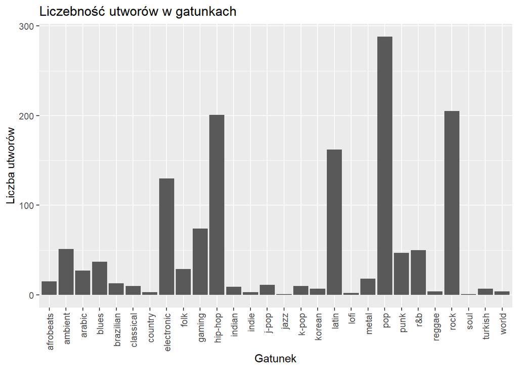

```r
ggplot(dane, aes(x = playlist_genre)) +
  geom_bar() +
  theme(axis.text.x = element_text(angle = 90, vjust = 0.5,
      hjust = 1))+
  labs(title = "Liczebność utworów w gatunkach",
       x = "Gatunek",
       y = "Liczba utworów")
```

Na powyższym wykresie jest pokazana liczba utworów o danym gatunku.

W naszym zestawie danych znajduje się 28 gatunków muzyki.

Dominuje tutaj definitywnie pop, z liczbą 288 piosenek. Oznacza to, że jest to najczęściej słuchany gatunek. Kolejnymi są Rock (205) i Hip-hop (201). Najmniej słuchanymi (lecz wciąż popularnymi gatunkami) są jazz i soul (1).

### 2. Którzy artyści mają w tym zestawieniu po kilka utworów? Kto ma najwięcej?

```r
artysci_max_utworow <- dane %>%
  count(track_artist, sort = TRUE)

head(artysci_max_utworow, 5)
```

```
## # A tibble: 5 × 2
##   track_artist              n
##   <chr>                 <int>
## 1 Bad Bunny                20
## 2 Linkin Park              10
## 3 Red Hot Chili Peppers     9
## 4 Brent Faiyaz              8
## 5 Green Day                 8
```

```r
gatunki_Bad_Bunny <- dane %>%
  filter(track_artist=="Bad Bunny")%>%
  group_by(playlist_genre)%>%
  summarise(liczba_utworow = n())

head(gatunki_Bad_Bunny, 5)
```

```
## # A tibble: 3 × 2
##   playlist_genre liczba_utworow
##   <chr>                   <int>
## 1 hip-hop                     1
## 2 latin                      18
## 3 world                       1
```

```r
muzyka_latin <- dane%>%
  filter(playlist_genre=="latin")%>%
  count(track_artist, sort = TRUE)

head(muzyka_latin, 5)
```

```
## # A tibble: 5 × 2
##   track_artist                n
##   <chr>                   <int>
## 1 Bad Bunny                  18
## 2 Bad Bunny, JHAYCO           2
## 3 Bad Bunny, Mora             2
## 4 FloyyMenor, Lewis Somes     2
## 5 HUMBE                       2
```

```r
artysci_z_jednym_hitem <- sum(artysci_max_utworow$n==1)
print(artysci_z_jednym_hitem)
```

```
## [1] 848
```

```r
srednia_ilosc_utworow <- mean(artysci_max_utworow$n, na.rm = TRUE)
odchylenie_ilosci_utworow <- sd(artysci_max_utworow$n, na.rm = TRUE)
```

Mimo, iż najpopularniejszym gatunkiem jest zdecydowanie pop, artystą z największą liczbą utworów jest Bad Bunny, który tworzy muzykę latynoską. (muzyka latynoska jest na 4 miejscu najpopularniejszych gatunków) Mozna wyciagnąć wniosek, że do mainstreamu w kategorii muzyka latynoska przebił się głównie jeden artysta. Pozostali popularni wykonawcy muzyki latynoskiej mają wybite do mainstreamu góra 3 utwory.

Pop jest popularny, zatem jest to gatunek, który tworzy mnóstwo artystów.Nie ma on jednego definiującego go artystę. Jest się też więc znacznie trudniej wybić.

Artysta wybija się średnio z jednym hitem, ponieważ średnia utworów przypadająca na jednego artystę to 1.375. Odchylenie standardowe to 1.164. Jest zatem niewielkie. Oznacza to, że mało jest artystów, którzy wybijają się z więcej niż dwoma piosenkami. Jest ich zaledwie 80 z 1032 wszystkich artystów w tym zestawieniu.

### 3. Najpopularniejsze albumy

```r
najpopularniejsze_albumy <- dane%>%
  count(track_album_name, sort = TRUE)
head(najpopularniejsze_albumy, 5)
```

```
## # A tibble: 5 × 2
##   track_album_name             n
##   <chr>                    <int>
## 1 Un Verano Sin Ti            15
## 2 YHLQMDLG                     8
## 3 CHROMAKOPIA                  5
## 4 EL ÚLTIMO TOUR DEL MUNDO     5
## 5 Hollywood's Bleeding         5
```

```r
dane_filtered <- dane[, c("track_name", "playlist_genre", "track_album_name", "track_artist")]

gatunek_UnVerano <- dane_filtered%>%
  filter(track_album_name=="Un Verano Sin Ti")

gatunek_YHLQMDLG <- dane_filtered%>%
  filter(track_album_name=="YHLQMDLG")

gatunek_CHROMAKOPIA  <- dane_filtered%>%
  filter(track_album_name=="CHROMAKOPIA")

head(gatunek_UnVerano, 5)
```

```
## # A tibble: 5 × 4
##   track_name       playlist_genre track_album_name track_artist
##   <chr>            <chr>          <chr>            <chr>
## 1 Ojitos Lindos    latin          Un Verano Sin Ti Bad Bunny, Bomba Estéreo
## 2 Otro Atardecer   latin          Un Verano Sin Ti Bad Bunny, The Marías
## 3 Yo No Soy Celoso latin          Un Verano Sin Ti Bad Bunny
## 4 Neverita         latin          Un Verano Sin Ti Bad Bunny
## 5 Un Coco          latin          Un Verano Sin Ti Bad Bunny
```

```r
head(gatunek_YHLQMDLG, 5)
```

```
## # A tibble: 5 × 4
##   track_name       playlist_genre track_album_name track_artist
##   <chr>            <chr>          <chr>            <chr>
## 1 Safaera          latin          YHLQMDLG         Bad Bunny, Jowell & Randy, Ñ…
## 2 La Difícil       latin          YHLQMDLG         Bad Bunny
## 3 A Tu Merced      latin          YHLQMDLG         Bad Bunny
## 4 Si Veo a Tu Mamá latin          YHLQMDLG         Bad Bunny
## 5 La Zona          latin          YHLQMDLG         Bad Bunny
```

```r
head(gatunek_CHROMAKOPIA, 5)
```

```
## # A tibble: 5 × 4
##   track_name                        playlist_genre track_album_name track_artist
##   <chr>                             <chr>          <chr>            <chr>
## 1 Sticky (feat. GloRilla, Sexyy Re… pop            CHROMAKOPIA      Tyler, The …
## 2 Thought I Was Dead (feat. ScHool… hip-hop        CHROMAKOPIA      Tyler, The …
## 3 Rah Tah Tah                       hip-hop        CHROMAKOPIA      Tyler, The …
## 4 Like Him (feat. Lola Young)       pop            CHROMAKOPIA      Tyler, The …
## 5 Darling, I (feat. Teezo Touchdow… hip-hop        CHROMAKOPIA      Tyler, The …
```

Najpopularniejszym albumem jest Un Verano Sin Ti, czyli Album artysty z największą liczbą popularnych utworów - Bad Bunny.Ponadto aż dwa albumy wrtysty znajdują się na pierwszych miejscach. Kolejnym jest YHLQMDLG. Można więc stwierdzić, że w gatunku muzyka latynoska przeważa muzyka artysty. Inne gatunki mają większą różnorodność i są tworzone przez większą liczbę artystów. Na miejscu 3 mamy Hip-hop i pop.

### 4. Analiza podgatunków

```r
table(dane$playlist_subgenre)
```

```
##
##            80s            90s       academic        african     afro-latin
##             28             18             39              7              6
##     afro house    alternative       american          anime     australian
##              7             35              6             11              3
##        bedroom        bhangra      bollywood          chill        classic
##             10              2              5             62            153
##         cumbia           desi          drama          drill      essential
##              3             17              7              3              3
##      feel-good         french           funk    future bass       gangster
##             20             19             13              1             39
##         global          heavy        hip-hop          indie     mainstream
##             23              2              4             27             47
##     meditative        melodic         modern  neo-classical       nigerian
##             11             18            295              6              8
##         nordic            pop       pop punk      reggaeton         scandi
##              1              7             47             90              1
##           soft       southern        spanish         techno throat singing
##             90              3             20             33              4
##      throwback           trap       tropical      vaporwave        workout
##            117             33              4              9              2
```

```r
tabela_podgatunki <- dane %>%
  count(playlist_genre, playlist_subgenre, name = "liczba_utworow", sort = TRUE)

podgatunki_na_gatunek <- dane %>%
  distinct(playlist_genre, playlist_subgenre) %>%
  count(playlist_genre, name = "liczba_podgatunkow", sort = TRUE)



head(tabela_podgatunki, 5)
```

```
## # A tibble: 5 × 3
##   playlist_genre playlist_subgenre liczba_utworow
##   <chr>          <chr>                      <int>
## 1 pop            throwback                    117
## 2 rock           classic                       91
## 3 latin          reggaeton                     90
## 4 pop            soft                          90
## 5 gaming         modern                        74
```

```r
head(podgatunki_na_gatunek, 5)
```

```
## # A tibble: 5 × 2
##   playlist_genre liczba_podgatunkow
##   <chr>                       <int>
## 1 hip-hop                         9
## 2 rock                            8
## 3 electronic                      7
## 4 latin                           6
## 5 pop                             6
```

```r
srednia__podgatunkow <- mean(podgatunki_na_gatunek$liczba_podgatunkow)
odchylenie_podgatunkow <- sd(podgatunki_na_gatunek$liczba_podgatunkow)

print(srednia__podgatunkow)
```

```
## [1] 2.464286
```

```r
print(odchylenie_podgatunkow)
```

```
## [1] 2.411118
```

### 5. Analiza podgatunków muzyki pop

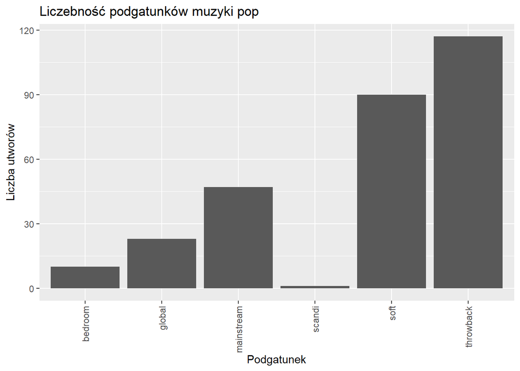

```r
ggplot(dane[dane$playlist_genre == "pop", ], aes(x = playlist_subgenre)) +
  geom_bar() +
  theme(axis.text.x = element_text(angle = 90, vjust = 0.5,
      hjust = 1))+
  labs(title = "Liczebność podgatunków muzyki pop",
       x = "Podgatunek",
       y = "Liczba utworów")
```

Dzięki wykresowi możemy zauważyć, że najpopularniejszym podgatunkiem popu jest throwback z liczbą 117 utworów. Najpopularniejszy Rock to zaś Rock klasyczny (91 utworów). Pop jest podzielony w tym zestawieniu na 6 podgatunków, z czego scandi jest zdecydownie tym najmniej popularnym. Throwback przewyższa ilością soft, a nawet mainstream.

### 6. Przeciętny czas trwania utworu

```r
dane$duration_min <- (dane$duration_ms)/60000

a <- mean(dane$duration_min)

print(a)
```

```
## [1] 3.572389
```

```r
print( sd(dane$duration_min))
```

```
## [1] 0.9829088
```

```r
print(quantile(dane$duration_min, probs = c(0.25, 0.5, 0.75)))
```

```
##      25%      50%      75%
## 2.939883 3.516667 4.073367
```

Przecietny czas jednego utworu to 3 i pół minuty. Dokładnie 3:35 minut.

### 7. Popularność

```r
dane[order(-dane$track_popularity), c("track_name", "playlist_genre", "track_popularity", "track_artist")]
```

```
## # A tibble: 1,419 × 4
##    track_name                    playlist_genre track_popularity track_artist
##    <chr>                         <chr>                     <dbl> <chr>
##  1 Die With A Smile              pop                         100 Lady Gaga, Bru…
##  2 APT.                          pop                          98 ROSÉ, Bruno Ma…
##  3 BIRDS OF A FEATHER            pop                          97 Billie Eilish
##  4 Good Luck, Babe!              pop                          94 Chappell Roan
##  5 That’s So True                pop                          93 Gracie Abrams
##  6 WILDFLOWER                    pop                          93 Billie Eilish
##  7 Tu Boda                       pop                          93 Oscar Maydon, …
##  8 Si Antes Te Hubiera Conocido  pop                          93 KAROL G
##  9 Timeless (with Playboi Carti) pop                          92 The Weeknd, Pl…
## 10 Who                           pop                          92 Jimin
## # ℹ 1,409 more rows
```

```r
agg <- aggregate(track_popularity ~ playlist_genre, dane, median)
agg[order(-agg$track_popularity), ]
```

```
##    playlist_genre track_popularity
## 10         gaming             79.0
## 21            pop             78.0
## 16          k-pop             76.5
## 23            r&b             76.0
## 18          latin             74.0
## 25           rock             74.0
## 8      electronic             73.0
## 9            folk             73.0
## 22           punk             73.0
## 20          metal             72.5
## 2         ambient             72.0
## 3          arabic             72.0
## 4           blues             72.0
## 5       brazilian             72.0
## 11        hip-hop             72.0
## 27        turkish             72.0
## 19           lofi             71.5
## 13          indie             71.0
## 14          j-pop             71.0
## 6       classical             70.5
## 28          world             70.5
## 1       afrobeats             70.0
## 7         country             70.0
## 12         indian             70.0
## 26           soul             70.0
## 15           jazz             69.0
## 17         korean             69.0
## 24         reggae             69.0
```

```r
head(dane[order(-dane$track_popularity), c("track_name", "playlist_genre", "track_popularity", "track_artist")], 5)
```

```
## # A tibble: 5 × 4
##   track_name         playlist_genre track_popularity track_artist
##   <chr>              <chr>                     <dbl> <chr>
## 1 Die With A Smile   pop                         100 Lady Gaga, Bruno Mars
## 2 APT.               pop                          98 ROSÉ, Bruno Mars
## 3 BIRDS OF A FEATHER pop                          97 Billie Eilish
## 4 Good Luck, Babe!   pop                          94 Chappell Roan
## 5 That’s So True     pop                          93 Gracie Abrams
```

```r
head(agg[order(-agg$track_popularity), ], 5)
```

```
##    playlist_genre track_popularity
## 10         gaming             79.0
## 21            pop             78.0
## 16          k-pop             76.5
## 23            r&b             76.0
## 18          latin             74.0
```

Najpopularniejszymi utworami. są “Die with a smile” Lady Gagi i Bruno Marsa oraz “APT.” ROSE i Bruno Marsa. Można zatem stwierdzić, że Bruno Mars jest wykonawca dwóch najpopularniejszych piosenek roku 2025.

### 8. Tonacja

```r
najpopularniejsza_tonacja <- dane %>%
  count(tonacja, sort = TRUE)
print(najpopularniejsza_tonacja)
```

```
## # A tibble: 12 × 2
##    tonacja         n
##    <chr>       <int>
##  1 C♯/D♭ - mol   188
##  2 B - mol       137
##  3 C - mol       132
##  4 F - mol       132
##  5 G - mol       132
##  6 D - mol       129
##  7 A - mol       119
##  8 F♯/G♭ - mol   106
##  9 E - mol       102
## 10 G♯/A♭ - mol   101
## 11 A♯/B♭ - mol    97
## 12 D♯/E♭ - mol    44
```

```r
dur_mol <- dane %>%
  count(mode,)
print(dur_mol)
```

```
## # A tibble: 2 × 2
##   mode      n
##   <fct> <int>
## 1 mol     595
## 2 dur     824
```

## Pytania badawcze

### 1. Czy poszczególne gatunki popularnej muzyki pisane są częściej w konkretnej tonacji?

Zależność między gatunkiem,a tonacją

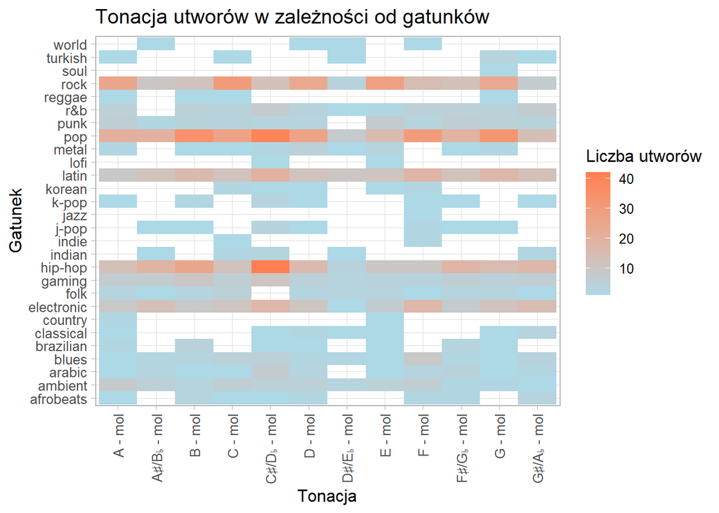

```r
tonacja_gatunek <- dane %>%
  count(playlist_genre, tonacja, sort = TRUE)


ggplot(tonacja_gatunek, aes(x = tonacja, y = playlist_genre, fill = n)) +
  geom_tile() +
  scale_fill_gradient(low = "lightblue", high = "coral") +
  theme_light(base_size = 12) +
  theme(axis.text.x = element_text(angle = 90, hjust = 1, vjust = 0.5)) +
  labs(title = "Tonacja utworów w zależności od gatunków",
       x = "Tonacja",
       y = "Gatunek",
       fill = "Liczba utworów")
```

### 2. Gatunki, a rodzaje gamy (dur/mol)

Sprawdzimy, czy niektóre gatunki częściej są pisane w tonacji durowej, bądź molowej. Zbadamy więc charakter gatunków

```r
gatunki_durmol <- dane %>%
  group_by(playlist_genre)%>%
  count(mode, sort = TRUE)
print(gatunki_durmol)
```

```
## # A tibble: 53 × 3
## # Groups:   playlist_genre [28]
##    playlist_genre mode      n
##    <chr>          <fct> <int>
##  1 pop            dur     193
##  2 rock           dur     148
##  3 hip-hop        dur     104
##  4 hip-hop        mol      97
##  5 pop            mol      95
##  6 latin          mol      89
##  7 electronic     mol      78
##  8 latin          dur      73
##  9 rock           mol      57
## 10 electronic     dur      52
## # ℹ 43 more rows
```

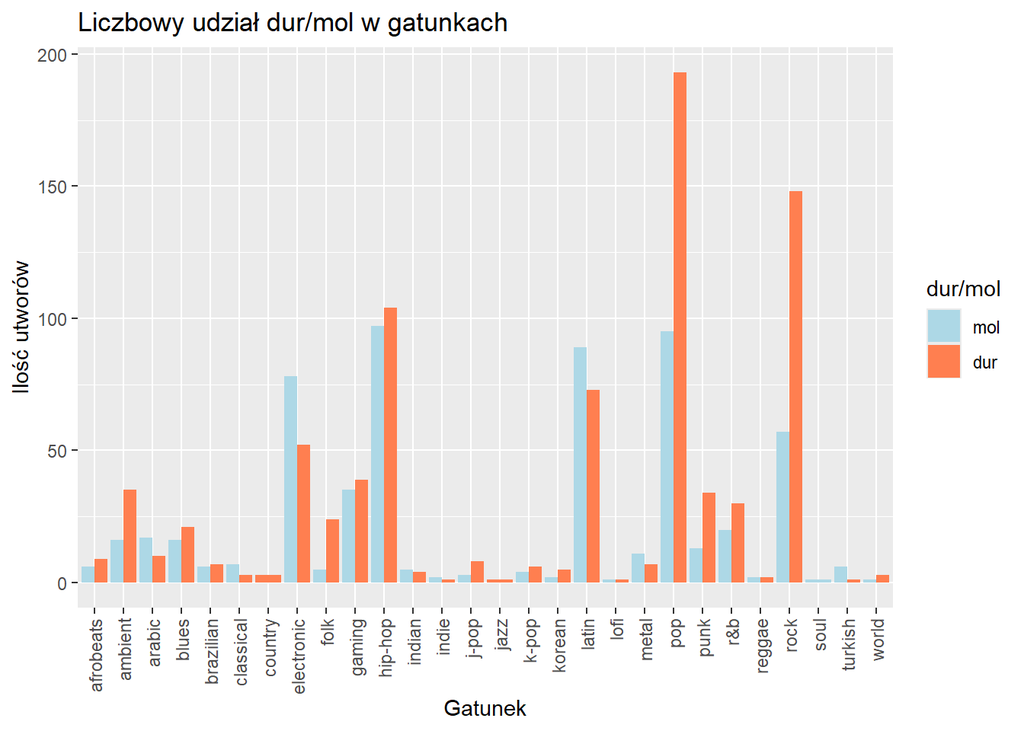

```r
ggplot(gatunki_durmol, aes(x = playlist_genre, y = n, fill = mode))+
  geom_bar(stat = "identity", position = position_dodge(width = 0.9))+
  scale_fill_manual(values = c("dur"="coral", "mol"="lightblue"))+
  labs(title = "Liczbowy udział dur/mol w gatunkach",
       x = "Gatunek", y = "Ilość utworów", fill = "dur/mol") +
  theme(axis.text.x = element_text(angle = 90, hjust = 1, vjust = 0.5))
```

W muzyce pop przeważa tonacja durowa, podobnie jak w rocku. Hip-hop ma niemal równomierny podział. Przeważa tu dur, lecz jest to bardzo mała różnica. W muzyce latynoskiej przeważają molowe brzmienia, lecz podobnie i w tym przypadku różnica jest niewielka. Muzyka elektroniczna ma więcej molowych brzmień.

### 3. Zależność między tempem, a gatunkiem muzycznym

[figure not shown]

```r
ggplot(dane, aes(x = playlist_genre, y = tempo)) +
  geom_boxplot(show.legend = FALSE) +
  labs(
    title = "Zależność energii od gatunku",
    x = "Gatunek",
    y = "Tempo"
  ) +
  theme_light() +
  theme(
    axis.text.x = element_text(angle = 90, hjust = 1))
```

```r
mean(dane$tempo[dane$playlist_genre == "pop"], na.rm = TRUE)
```

```
## [1] 119.5929
```

```r
mean(dane$tempo[dane$playlist_genre == "electronic"], na.rm = TRUE)
```

```
## [1] 120.9842
```

Na podstawie wykresów pudełkowych możey zauważyć, że najwięcej wartości odstających znajduje się przy muzyce elektronicznej i popie. Oba gatunki mają bardzo podobne średnie tempo utworów, czyli około 120 BPM. Muzyka elektroniczna charakterycuje się małym odchyleniem tempa i wyjątkami (wartościami odstającymi), czyli utworami o mniejszym tempie. Pop zaś ma odchylenie większe, a jego wartości odstające to utwory o większym tempie. Oznacza to, że te dwa gatunki mają na ogół podobne tempo, lecz jeśli popatrzymy na wartości odstające, to możemy wywnioskować, że twórcy popu są skłonni do zwiększenia tempa, a twórcy muzyki elektronicznej do jego zniejszenia.

Największy odchyleniem standardowym charakteryzuje się muzyka klasyczna, lecz w tym zestawie jest tylko 10 utworów w tej kategorii, zatem nie daje nam to realnego obrazu. Stwierdzenie: W muzyce mainstreamowej największą różnorodnością tempa charakteryzuje się muzyka klasyczna.

### 4. Czy poszczególni artyści mają skłonność do pisania utworów w danym trybie?

Zależność między artystą, a trybem (dur/mol)

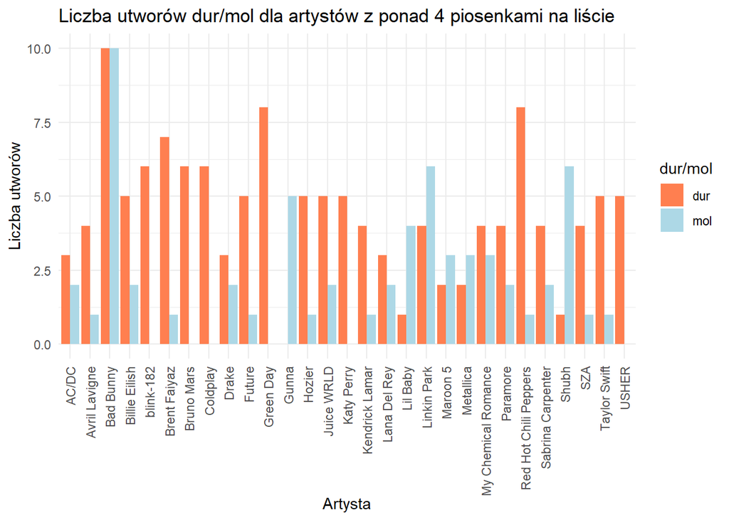

```r
artysta_mode <- dane %>%
  group_by(track_artist) %>%
  filter(n() > 4) %>%
  ungroup() %>%
  group_by(track_artist, mode) %>%
  summarise(n = n(), .groups = "drop") %>%
  complete(track_artist, mode = c("dur", "mol"), fill = list(n = 0))


ggplot(artysta_mode, aes(x = track_artist, y = n, fill = mode)) +
  geom_bar(stat = "identity", position = position_dodge(width = 0.9))+
  scale_fill_manual(values = c("dur" = "coral", "mol" = "lightblue")) +
  labs(title = "Liczba utworów dur/mol dla artystów z ponad 4 piosenkami na liście",
       x = "Artysta", y = "Liczba utworów", fill = "dur/mol") +
  theme_minimal() +
  theme(axis.text.x = element_text(angle = 90, hjust = 1, vjust = 0.5))
```

Piosenki Gunna są tylko molowe (na tej liście 5). Piosenki Green Day są zaś wyłacznie durowe (8), tak jak USHERa (5), Coldplay (6), Bruno Mars(6). Bad Bunny ma wręcz równomierny podział utworów w zależności od trybu. Piosenki Lil Baby,Shubh, Linkin Park, Metalica’i i Maroon 5 są tutaj głównie molowe. U pozostałych artystów przeważa muzyka durowa.

### 5. Zależność między gatunkiem, a energią

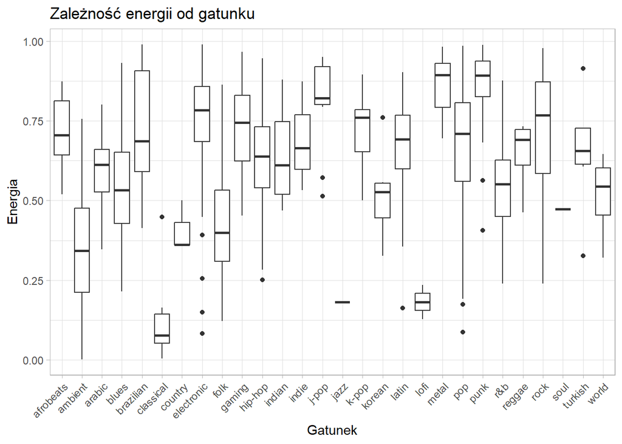

```r
ggplot(dane, aes(x = playlist_genre, y = energy)) +
  geom_boxplot(show.legend = FALSE) +
  labs(
    title = "Zależność energii od gatunku",
    x = "Gatunek",
    y = "Energia"
  ) +
  theme_light() +
  theme(
    axis.text.x = element_text(angle = 45, hjust = 1)
  )
```

Możemy zauważyć, że w tym zestawieniu muzyka klasyczna odznacza się najmniejszą energicznością, a tuż za nią jest lofi oraz jazz. Największą średnią energią wyróżniają się punk i metal, a zaraz potem j-pop (japoński pop). Muzyka brazylijska, Rock pop i ambient mają największe odchylenie standardowe. Oznacza to, że to te gatunki są na tej liście najbardziej zróżnicowane pod względem energii.

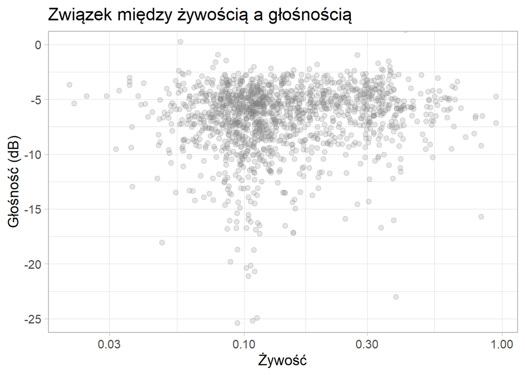

```r
dane %>%
  ggplot() +
  geom_point(aes(x = liveness, y = loudness), size = 2,
             color = "grey50", alpha = 0.2) +
  scale_x_log10() +
  theme_light(base_size = 14) +
  coord_cartesian(ylim = c(-25, 0))+
labs(
  title = "Związek między żywością a głośnością",
  x = "Żywość",
  y = "Głośność (dB)"
)
```

Można zauważyć, że głośność skupia się głównie w jednym miejscu, w wyższych rejonach skali. Utwory mają zatem podobną głośnośc. Jedynie pojedyncze piosenki są cichsze (może to jednak wynikać z innego nagrania utworu).Tylko poszczególne, mało żywe utwory charakteryzują się mniejszą głośnością. Utwory żywsze nie mają tendencji do bycia cichszymi. Utwory bardziej żywe utrzymują głośność na przeciętnym poziomie.

### 7. Związek między głośnością, a tempem

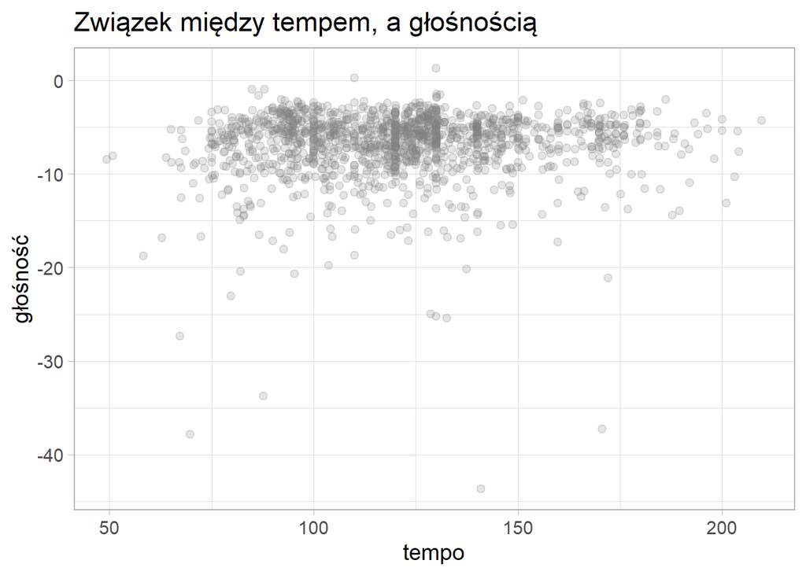

```r
dane %>%
  ggplot() +
  geom_point(aes(x = tempo, y = loudness), size = 2,
             color = "grey50", alpha = 0.2) +
  theme_light(base_size = 14) +
  labs(title = "Związek między tempem, a głośnością",
       x = "tempo",
       y = "głośność")
```

Nie ma zależności między głośnością, a tempem. Można tylko wywnioskować, że tempo mieści się zazwyczaj pomiędzy 75 BPM, a 175 BPM. Głośność utrzymuje się na jednakowym poziomie, Jedynie pojedyncze utwory są cichsze, lecz nie da się zauważyć związku z tempem.

### 8. Popularność utworów, a gatunek

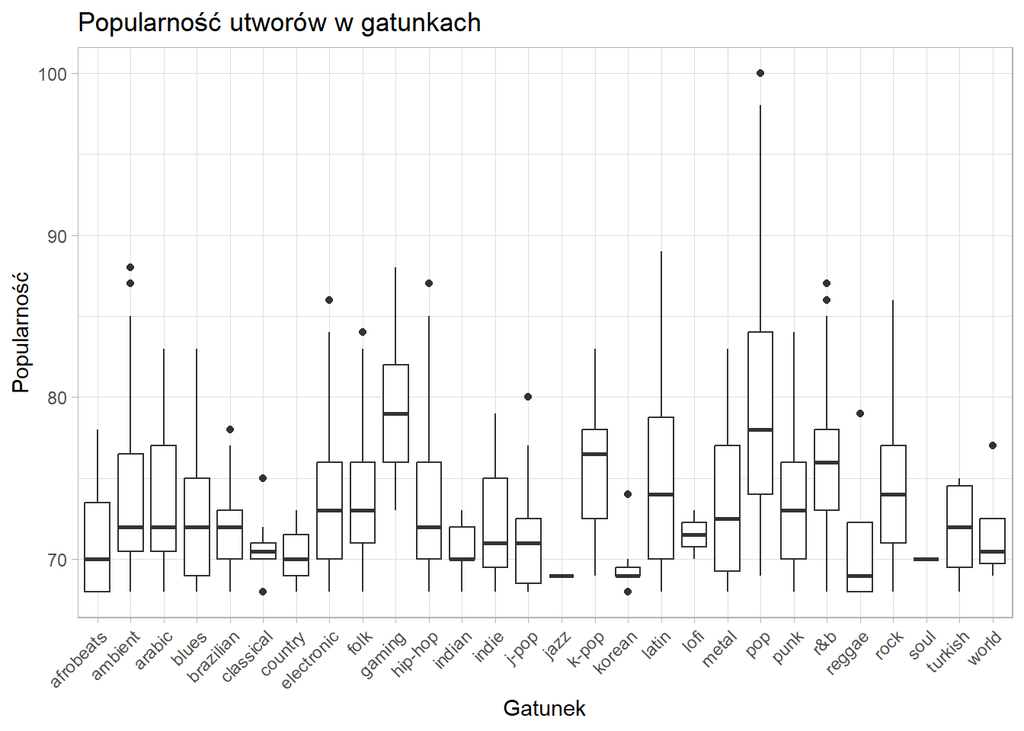

```r
ggplot(dane, aes(x = playlist_genre, y = track_popularity)) +
  geom_boxplot(show.legend = FALSE) +
  labs(
    title = "Popularność utworów w gatunkach",
    x = "Gatunek",
    y = "Popularność"
  ) +
  theme_light() +
  theme(
    axis.text.x = element_text(angle = 45, hjust = 1)
  )
```

Gatunkiem z największą średnią utworów o wysokiej popularności jest gaming, a zaraz po tym pop. To pop charakteryzuje się największym wąsem. Gatunkami, gdzie tylko kilka utworów się wybiło są ambient i r&b. Maja one aż dwie wartości odstające. Oznacza to, że większość utworów o tych gatunkach charakteryzuje się mniejszą popularnością, lecz czasem pojawiają się utwory, którw zdołają się wybić.

### 9. Rozkłąd Taneczności w zależności od trybu (dur/mol)

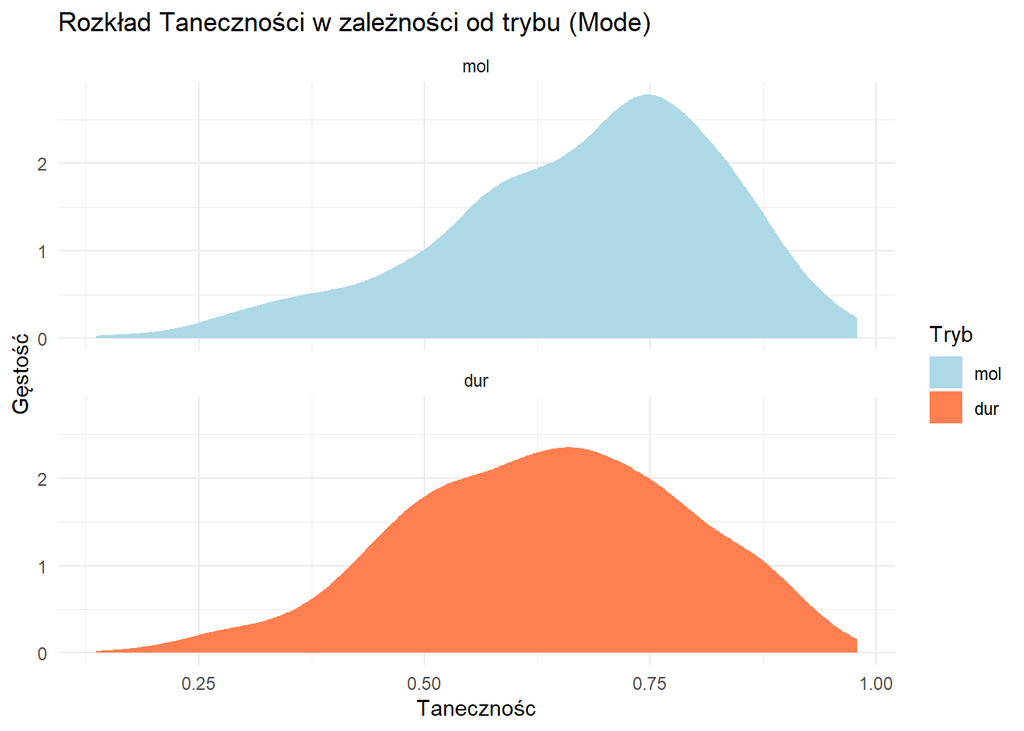

```r
ggplot(dane, aes(x = danceability, fill = mode)) +
  geom_density(color = NA) +
  facet_wrap(~mode, ncol = 1) +
  scale_fill_manual(values = c("lightblue", "coral")) +
  labs(
    title = "Rozkład Taneczności w zależności od trybu (Mode)",
    x = "Tanecznośc",
    y = "Gęstość",
    fill = "Tryb"
  ) +
  theme_minimal()
```

```r
test_t <- t.test(danceability ~ mode, data = dane)

print(test_t)
```

```
##
##  Welch Two Sample t-test
##
## data:  danceability by mode
## t = 4.877, df = 1278.2, p-value = 1.212e-06
## alternative hypothesis: true difference in means between group mol and group dur is not equal to 0
## 95 percent confidence interval:
##  0.02453458 0.05755614
## sample estimates:
## mean in group mol mean in group dur
##         0.6754689         0.6344235
```

Przeprowadzony został test t-Studenta, którego Hipotezą zerową jest fakt, iż utwory molowe charakteryzuja się taką samą ilością utworów o wysokiej taneczności, co utwory durowe. Wartość p-value wpada w obszar krytyczny, co pozwala na jednoznaczne odrzucenie hipotezy zerowej. Otrzymane wyniki wskazują na istotną różnicę taneczności, w zależności od trybu. Potwierdza to, że utwory molowe muzyki populrnej charakteryzują się średnio wyższym współczynnikiem taneczności niż utwory durowe.

Podział na dur = taniecć, mol = smutek uległ zmianie w XX wieku, a różnice te jeszcze bardziej zacierają się wraz z ubiegiem dekad.

## Podsumowanie

Celem projektu było przeprowadzenie dogłębnej analizy najbardziej popularnych utworów 2025 roku wg. platformy Spotify.

Analiza skupiła się na utworach, które odniosły największy sukces komercyjny. Dane pokazały, że są one zróżnicowane pod kątem technicznym, ale posiadają pewne wspólne cechy (budowa, głośność)

Projekt udowodnił, że sukces utworu jest wynikiem wielu czynników, a techniczne parametry muzyczne są tylko jednym z wielu elementów składowych, które nie dają jednoznacznego wzoru na stworzenie hitu. Analiza pozwala jednak na odnalezienie cech wspólnych piosenek muzyki popularnej.